# Week 6 Assingment - Bank Loan Data

Chloé Winters

2025-03-01

# 1 Introduction

In this assignment we are going to be looking at bank loan data, doing some data cleaning and editing, and then looking at some density curves.

# 2 Materials

First we need to load in the data set. This data is cut into 9 subsets so they all need to be loaded in. After loading them all in, some of the variables did not have matching categorizations, not all the ApprovalFY variables were coded the same so that variable needs to be standardized across all the subsets before merging them. After the variables are all consistent it is possible to combine all of the data sets into one larger data set.

```r
loan01 = read.csv("https://chloewinters79.github.io/STA490/Data/w06-SBAnational01%20.csv", header = TRUE)[, -1]
loan02 = read.csv("https://chloewinters79.github.io/STA490/Data/w06-SBAnational02.csv", header = TRUE)[, -1]
loan03 = read.csv("https://chloewinters79.github.io/STA490/Data/w06-SBAnational03.csv", header = TRUE)[, -1]
loan04 = read.csv("https://chloewinters79.github.io/STA490/Data/w06-SBAnational04.csv", header = TRUE)[, -1]
loan05 = read.csv("https://chloewinters79.github.io/STA490/Data/w06-SBAnational05.csv", header = TRUE)[, -1]
loan06 = read.csv("https://chloewinters79.github.io/STA490/Data/w06-SBAnational06.csv", header = TRUE)[, -1]
loan07 = read.csv("https://chloewinters79.github.io/STA490/Data/w06-SBAnational07.csv", header = TRUE)[, -1]
loan08 = read.csv("https://chloewinters79.github.io/STA490/Data/w06-SBAnational08.csv", header = TRUE)[, -1]
loan09 = read.csv("https://chloewinters79.github.io/STA490/Data/w06-SBAnational09.csv", header = TRUE)[, -1]
```

```r
loan01$ApprovalFY <- as.integer(loan01$ApprovalFY)
loan02$ApprovalFY <- as.integer(loan02$ApprovalFY)
loan03$ApprovalFY <- as.integer(loan03$ApprovalFY)
loan04$ApprovalFY <- as.integer(loan04$ApprovalFY)
loan05$ApprovalFY <- as.integer(loan05$ApprovalFY)
loan06$ApprovalFY <- as.integer(loan06$ApprovalFY)
loan07$ApprovalFY <- as.integer(loan07$ApprovalFY)
loan08$ApprovalFY <- as.integer(loan08$ApprovalFY)
loan09$ApprovalFY <- as.integer(loan09$ApprovalFY)
```

```r
loans <- bind_rows(loan01, loan02, loan03, loan04, loan05, loan06, loan07, loan08, loan09)
```

## 2.1 Data Cleaning

This assignment calls for some specific forms of data cleaning, which we can now work on since all the subsets have been combined into one large data set. First it is asked that all records with a missing MIS_Status are deleted so that is what we start with. Then, all the currency variables needed to be converted regular numeric variables. Which was done by creating a function that was then applied to the appropriate variables.

```r
# Deletes records with a missing MIS_Status
loans_cleaned <- loans%>%
  filter(!is.na(MIS_Status))

# Converts currency variables to regular numeric variables
fix_loans <- function(loans_cleaned) {
  as.numeric(gsub("[$,]", "", loans_cleaned))
}


loans_cleaned$DisbursementGross <- fix_loans(loans_cleaned$DisbursementGross)
loans_cleaned$BalanceGross <- fix_loans(loans_cleaned$BalanceGross)
loans_cleaned$ChgOffPrinGr <- fix_loans(loans_cleaned$ChgOffPrinGr)
loans_cleaned$GrAppv <- fix_loans(loans_cleaned$GrAppv)
loans_cleaned$SBA_Appv <- fix_loans(loans_cleaned$SBA_Appv)
```

## 2.2 Recoding

It is requested that one of the categorical variables be recoded so the categories were less sparse. I made the decision to recode the FranchiseCode variable into FranchiseCodeNew which would display a 0 if it was not a Franchise and a 1 if was a Franchise. Since there were several FranchiseCodes with only 1 or 2 observations and any FranchsieCode of 0 or 1 indicated that it was not a franchise it made more sense to consolidate this variable.

```r
freq_table <- table(loans_cleaned$FranchiseCode)
table(freq_table)
```

```
## freq_table
##      1      2      3      4      5      6      7      8      9     10     11
##    840    383    220    174    106    102     77     62     64     39     36
##     12     13     14     15     16     17     18     19     20     21     22
##     38     35     40     32     20     18     17     19     13     15     13
##     23     24     25     26     27     28     29     30     31     32     33
##     11     13     13     14      7     12     12     12      5      6      9
##     34     35     36     37     38     39     40     41     42     43     44
##     11      4      8     12      4      7      6      5      5      1      5
##     45     46     47     48     49     50     51     52     53     54     55
##      4      6      5      3      5      1      3      3      2      1      1
##     56     57     58     59     60     61     62     63     64     66     67
##      4      6      1      2      3      2      6      5      3      3      1
##     68     69     70     71     73     74     75     76     77     78     79
##      4      3      2      3      2      5      2      1      2      2      1
```

[output cut: 18 more lines]

```r
# Recode the old FranchiseCode to FranchiseCodeNew
loans_cleaned$FranchiseCodeNew <- ifelse(loans_cleaned$FranchiseCode %in% c(0, 1), 0, 1)
```

# 3 Methodolgy & Analysis

Now that the requested data cleaning has been completed it is time to engage in some of the requested analysis. It was requested that using the recoded variable that we created in the previous section that we calculate the loan default rates for the new categories. Looking at the output, it seems that non-franchises had a default rate of 17.67% and franchises had a default rate of 15.18%, so the franchises had a slightly lower default rate.

```r
# Calculate default rate by FranchiseCodeNew based on CHGOFF in MIS_Status
default_rates <- loans_cleaned %>%
  group_by(FranchiseCodeNew) %>%
  summarise(
    default_rate = sum(MIS_Status == "CHGOFF", na.rm = TRUE) / n() * 100  # Default rate as percentage
  )

# View the result
print(default_rates)
```

```
## # A tibble: 2 × 2
##   FranchiseCodeNew default_rate
##              <dbl>        <dbl>
## 1                0         17.7
## 2                1         15.2
```

In addition to recoding a categorical variable, it is asked that the variable GrAppv gets discretized into 5 categories or sub populations. In order to create these categories, I calculated the quantiles and used them to determine my breaking points to the quantiels were approximately the same size.

After creating these categories we were asked to create density curves of SBA_Appv with the 5 categories. Originally, we did not take the log of SBA_Appv but the variable was very skewed so it made more sense to take the log of SBA_Appv to make the graph more readable. The original density curve had a large axis making the curves very small and difficult to interpret. There was also a large amount of overlap of the separate categories which lead to the issues with interpretation. Thus taking the log results in much more interpretable density curves.

```r
# Calculate quantiles to determine break points
quantiles <- quantile(loans_cleaned$GrAppv, probs = seq(0, 1, by = 0.2), na.rm = TRUE)

# Print the quantiles (break points)
print(quantiles)
```

```
##      0%     20%     40%     60%     80%    100%
##     200   25000   56000  120000  285000 5472000
```

```r
# Define break points based on the quantiles
break_points <- c(200, 25000, 56000, 120000, 285000, 5472000)

# Discretize GrAppv using the quantile-based break points
loans_cleaned$GrAppv_discretized <- cut(
  loans_cleaned$GrAppv,
  breaks = break_points,  # Use custom break points
  labels = c("1", "2", "3", "4", "5"),  # Labels for the categories
  include.lowest = TRUE
)
```

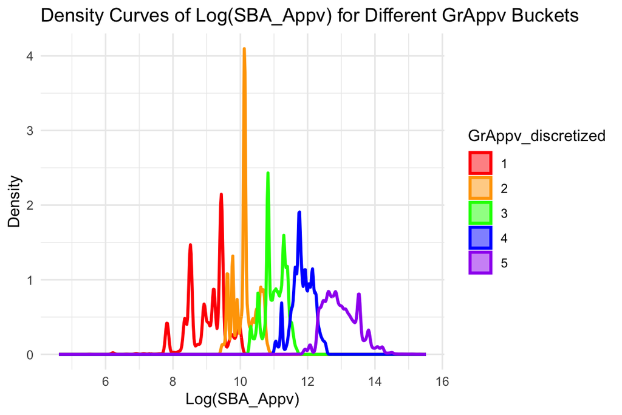

```r
# Load necessary library
library(ggplot2)

# Ensure GrAppv is discretized (if not already)
loans_cleaned$GrAppv_discretized <- cut(
  loans_cleaned$GrAppv,
  breaks = c(200, 25000, 56000, 120000, 285000, 5472000),
  labels = c("1", "2", "3", "4", "5"),
  include.lowest = TRUE
)

# Apply log transformation to SBA_Appv to handle skew
loans_cleaned$log_SBA_Appv <- log(loans_cleaned$SBA_Appv + 1)

# Create ggplot to overlay density curves for log-transformed SBA_Appv without fill color
ggplot(loans_cleaned, aes(x = log_SBA_Appv, color = GrAppv_discretized)) +
  geom_density(alpha = 0.5, size = 1) +  # Only lines with transparency
  labs(
    title = "Density Curves of Log(SBA_Appv) for Different GrAppv Buckets",
    x = "Log(SBA_Appv)",
    y = "Density"
  ) +
  theme_minimal() +
  scale_color_manual(values = c("red", "orange", "green", "blue", "purple")) +  # Customize line colors
  guides(
    color = guide_legend(
      override.aes = list(
        fill = c("red", "orange", "green", "blue", "purple")  # Use solid fill color in the legend
      )
    )
  )
```